# Weight of Evidence and Information Value in Scorecard Modelling

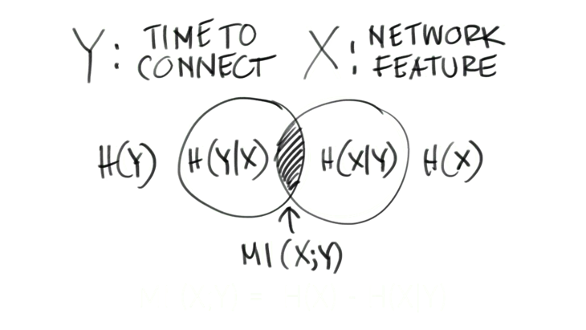

The weight of evidence (WOE) and information value (IV) provide a great framework for for exploratory analysis and variable screening for binary classifiers. WOE and IV have been used extensively in the credit risk world for several decades.

### WOE and IV

WOE and IV play two distinct roles when analyzing data:

- WOE describes the relationship between a predictive variable and a binary target variable.
- IV measures the strength of that relationship.

The WOE/IV framework is based on the following relationship:
$$\begin{equation}
log\frac{P(Y=1|X_{j})}{P(Y=0|X_{j})}=log\frac{P(Y=1)}{P(Y=0)}+log\frac{P(X_{j}|Y=1)}{P(X_{j}|Y=0)}
\end{equation}$$

where $P(X_{i}|Y)$ denotes the conditional probability density function (or a discrete probability distribution if $X_{j}$ is categorical). This relationship says that the conditional logit of P(Y=1 given $X_{j}$), can be written as the over all log-odds (i.e., the “intercept”) plus the log-density ratio – also known as the weight of evidence (WOE). In fact, when WOE is positive the chance of of observing Y=1 is above average (for the sample), and vice versa when WOE is negative. When WOE equals 0 the odds are simply equal to the sample average.

### Logistic function

The goal is to predict the target class $Y$ from an input $X$ and let $z= f(x)$. If $f$ is a linear equation, then $f(x) = \sum(\beta_i*X_i)$ and the probability $P(Y=1|z)$ represents that input X is classified as class 1. $Y=1$ is represented by the output $y$ of the logistic function computed as $y=\sigma(z)$. The logistic function $\sigma$ is defined as:

$$\sigma(z) = \frac{1}{1+e^{-z}}$$

We can write the probabilities that the class is $Y=1$ or $Y=0$ given input $z$ as:
$$P(Y=1|z) = \sigma(z) = \frac{1}{1+e^{-z}}$$

$$P(Y=0|z) = 1-\sigma(z) = \frac{e^{-z}}{1+e^{-z}}$$

Note that input $z$ to the logistic function corresponds to the log odds ratio of $P(Y=1|z)$ over $P(Y=0|z)$:
$$\log \frac{P(Y=1|z)}{P(t=0|z)} = \log \frac{1}{e^{-z}} = \log(1) - \log(e^{-z}) = z$$
This means that the log odds ratio $\log \frac{P(Y=1|z)}{P(Y=0|z)}$ changes linearly with $z$.

### Ties to Naive Bayes and Logistic Regression

Notice that the left-hand-side of the equation above - i.e., the conditional log odds $log\frac{P(Y=1|X_{j})}{P(Y=0|X_{j})}$ - is exactly what we are trying to predict in a logistic regression model.

Hence, when building a logistic regression model – which is perhaps the most widely used technique for building binary classifiers – we are actually trying to estimate the weight of evidence.

Last, but not least, the WOE framework has ties to the well-known naive Bayes classifier.

$$\begin{equation}
log\frac{P(Y=1|X_{1},...,X_{p})}{P(Y=0|X_{1},...,X_{p})}=log\frac{P(Y=1)}{P(Y=0)}+\sum_{j=1}^{p}log\frac{P(X_{j}|Y=1)}{P(X_{j}|Y=0)}
\end{equation}$$

The naive Bayes model essentially says that the conditional log odds is equal to the sum of the individual weight of evidence vectors. The word “naive” comes from the fact that this model relies on the assumption that all predictors are conditionally independent given Y, which is a highly optimistic assumption.

In the credit scoring industry a “semi-Naive” version of this model is quite popular. The idea is to transform the data into WOE vectors and then use logistic regression to fit the model:
$$\begin{equation}
log\frac{P(Y=1|X_{1},...,X_{p})}{P(Y=0|X_{1},...,X_{p})}=log\frac{P(Y=1)}{P(Y=0)}+\sum_{j=1}^{p}\beta_{j}log\frac{P(X_{j}|Y=1)}{P(X_{j}|Y=0)}
\end{equation}$$

thus partly relaxing the assumption that all predictors in the model are independent. It should be noted that the underlying WOE vectors are still estimated univariately and that the coefficients merely function as scalars.

### Reject Inference

Reject Inference is a technique to enable a declined population, for example rejected loan applications, to be included in modeling. In other words, reject inference is a process whereby the performance of the previously rejected applications is estimated, and used as ground truth to re-train the model.

When building credit scoring models, historical dataset of loans are used for training, some of which are Good loans (G) and some others are Bad loans (B). Ideally, a system can be developed — a Known Good-Bad (KGB) model — which can understand which patterns make a Good loan, and what patterns make a Bad loan.

Unfortunately, when developing the model the credit risk modelers are, by definition, working only with the loans that were Accepted (A), and can have no idea how the Rejected (R) loans would have performed. That leads to biases in the model, given that when it is used on the through the door population, most of the applications will not resemble the accepted dataset that it was trained on.

Customarily, banks make use of reject inference models using either proprietary statistical implementations or commercially available solutions. However, the benefit of using reject inference models is not clear, and up to the current day, the available literature is limited.

### Scaling

In practice, the log-odds value is often scaled to a given number. For example, the score 600 corresponds to good/bad odds of 60 to 1, and the Points to double the odds (PDO) is set as 20. The choice of scaling does not affect the predictive strength of the scorecard. However, the later means an increase of the score of 20 points corresponds to a doubling of the good/bad odds. Two new parameters, factor $\beta$ and offset $\alpha$, are introduced to archive this requirement.
$$Factor = PDO / ln(2)$$
$$Offset = Score - \{Factor * log(Odds)\}$$
The scorecard model often replaces the raw variables by their WOE, and the logistic regression is the weighted sum of the WOE. By including the scaling, the final scorecard model can be represented as:

$$\begin{equation}
Score = \sum^n_{i=1}(-(woe_{i}*\beta_{i}+\frac{a}{n})*Factor + \frac{Offset}{n}) = \sum^n_{i=1}(-(woe_{i}*\beta_{i}*Factor))+ a*Factor + Offset
\end{equation}$$

Let the score 600 corresponds to good/bad odds of 60 to 1:
$$600 = \alpha - (\beta* \log(1/60))$$
and an increase of the score of 20 points corresponds to a doubling of the good/bad odds.
$$620 = \alpha - (\beta* \log(1/120))$$

### WOE/IV with Entropy

Weight of evidence (WOE) and information value are closely related to concepts from information theory where one of the goals is to understand the uncertainty involved in predicting the outcome of random events given varying degrees of knowledge of other variables. Thus this is a perfect framework for variable screening and exploratory analysis for predictive modeling.

Information theory kicked off when Claude Shannon (1948) wrote down an expression for the entropy of a probability distribution. Entropy is often described as the level of disorder but in the context of information theory it is better to think of it as one’s level of uncertainty. High entropy means high uncertainty (you don’t know what tomorrow holds) and low entropy mean low uncertainty (there will be no surprises tomorrow).

Suppose a friend tosses a coin and asks you to predict whether the toss came up heads or tails.There’s 50 percent probability of each possibility, so your prediction isn’t worth very much. This turns out to be the maximum amount of entropy for an event with two possible outcomes. Suppose instead that you know the coin is weighted so that it comes up heads 90 percent of the time. Now your job of making a prediction is easier – Shannon’s formula tells you exactly how much information you’ve gained compared to the previous situation.

Mutual information is a way of summarizing much knowing the value of one random variable tells you about another random variable (Shannon + Weaver 1949). If XX and YY are independent, the mutual information is zero. Any correlations (positive, negative, or nonlinear) will result in positive mutual information. It turns out the mutual information of X and YY is nicely expressed in terms of entropy (H):

$$MI(X,Y)=H(X)+H(Y)-H(X,Y)$$

Mutual information is the difference in predictability that you get from knowing the joint distribution p(X,Y) compared to knowing only the two marginal distributions p(X) and p(Y). Information value (IV), which we will define below, is quite closely connected to mutual information (MI), and both are intended to do the same thing: summarize how much knowing the value of X in a given trial helps you predict the value of Y for the same trial.

### Estimate a scorecard model with WOE

Here we will use a public dataset, German Credit Data, with a binary response variable, good or bad risk. We will evaluate and compare the models with typical credit risk model measures, AUC and Kolmogorov-Smirnov test (KS).

```r
library(tidyverse)
# Packages for loading data
library(httr)
# Packages for data manipulation
library(purrr)
# Packages for visualization
library(Information)
library(gmodels)
library(DataExplorer)
# Packages for modeling
library(pROC)
library(scorecard)
```

### Load data

Load the Statlog (German Credit Data) Data Set with httr and readr R packages. Note readr is available from loading and attaching the package to the search path with library(tidyverse) above.

```r
# Set the url and uset GET function from httr to import the csv file to a temporary local directory, and read_csv from readr R package. This csv is also available at this url, with variable names. The UCI link does not include variable names and this will save us a step.
url <- ("http://www.biz.uiowa.edu/faculty/jledolter/DataMining/germancredit.csv")
GET(url, write_disk(tf <- tempfile(fileext = ".data")))
```

### Summary of data

The dataset metadata describes this data. This dataset appears to represent approved loan data, and would therefore exclude rejected applications.

Let’s first take a look at a summary using skim function from the skimr package.

```r
creditdata <- read_csv(tf)
# Plot the summary excluding the histograms as these do not print in R Markdown html yet
# skimr::skim_with(integer = list(hist = NULL))
skimr::skim(creditdata)
```

```
-- Data Summary ------------------------
                           Values
Name                       creditdata
Number of rows             1000
Number of columns          21
_______________________
Column type frequency:
  character                13
  numeric                  8
________________________
Group variables            None

-- Variable type: character ---------------------------------------------------------------------------------------------------------------------
# A tibble: 13 x 8
   skim_variable   n_missing complete_rate   min   max empty n_unique whitespace
 * <chr>               <int>         <dbl> <int> <int> <int>    <int>      <int>
 1 checkingstatus1         0             1     3     3     0        4          0
 2 history                 0             1     3     3     0        5          0
 3 purpose                 0             1     3     4     0       10          0
 4 savings                 0             1     3     3     0        5          0
 5 employ                  0             1     3     3     0        5          0
 6 status                  0             1     3     3     0        4          0
 7 others                  0             1     4     4     0        3          0
 8 property                0             1     4     4     0        4          0
 9 otherplans              0             1     4     4     0        3          0
10 housing                 0             1     4     4     0        3          0
11 job                     0             1     4     4     0        4          0
12 tele                    0             1     4     4     0        2          0
13 foreign                 0             1     4     4     0        2          0

-- Variable type: numeric -----------------------------------------------------------------------------------------------------------------------
# A tibble: 8 x 11
  skim_variable n_missing complete_rate    mean       sd    p0   p25   p50   p75  p100 hist
* <chr>             <int>         <dbl>   <dbl>    <dbl> <dbl> <dbl> <dbl> <dbl> <dbl> <chr>
1 Default               0             1    0.3     0.458     0    0     0     1      1 ▇▁▁▁▃
2 duration              0             1   20.9    12.1       4   12    18    24     72 ▇▇▂▁▁
3 amount                0             1 3271.   2823.      250 1366. 2320. 3972. 18424 ▇▂▁▁▁
4 installment           0             1    2.97    1.12      1    2     3     4      4 ▂▃▁▂▇
5 residence             0             1    2.84    1.10      1    2     3     4      4 ▂▆▁▃▇
6 age                   0             1   35.5    11.4      19   27    33    42     75 ▇▆▃▁▁
7 cards                 0             1    1.41    0.578     1    1     1     2      4 ▇▅▁▁▁
8 liable                0             1    1.16    0.362     1    1     1     1      2 ▇▁▁▁▂
```

### Clean Data

Next we will clean the dataset using dplyr and purrr R packages.

From the metadata, the following variables are numeric:

Attribute 2: duration (numerical) Duration in month Attribute 5: amount (numerical) Credit amount Attribute 8: instalment (numerical) Instalment rate in percentage of disposable income Attribute 11: residence (numerical) Present residence since Attribute 13: age (numerical) Age in years Attribute 18: liable (numerical) Number of people being liable to provide maintenance for

```r
# Rename the default variable to lower case for naming consistency
names(creditdata) <- tolower(names(creditdata))
```

Next recode the variable levels with the forcats R package so that the variables are easier to understand in the plots. We have recoded as per the metadata.

```r
# Recode with fct_recode function
creditdata$checkingstatus1 <- fct_recode(creditdata$checkingstatus1, less0='A11', low0to200DM='A12', highover200DM='A13', noaccount='A14')
creditdata$history <- fct_recode(creditdata$history, nocredit='A30', creditpaid='A31',creditpaidtilnow ='A32', pastdelays='A33',otherbankcredit='A34')
creditdata$purpose <- fct_recode(creditdata$purpose, car_new='A40', car_used='A41',furniture ='A42', radio_tv='A43',appliance='A44', repairs='A45', education='A46',  retraining='A48', business='A49', others='A410') #vacation='A47'does not exist in data
creditdata$others <- fct_recode(creditdata$others, noguarantors='A101', coapplicant='A102',guarantor ='A103')
creditdata$property <- fct_recode(creditdata$property, realestate='A121', othersavings='A122',othercar ='A123',noproperty='A124')
creditdata$otherplans <- fct_recode(creditdata$otherplans, bankplans='A141', storeplans='A142',noplans ='A143')
creditdata$status <- fct_recode(creditdata$status, male_other='A91',female_other='A92', male_single='A93', male_other='A94', female_single='A95')
```

```
Unknown levels in `f`: A95
```

### MISSING VALUES

As per the metadata, there are no missing values. Let’s confirm with a missing values plot, plot_missing from Data Explorer package.

The DataExplorer speeds up data exploration process and automatically scans through each variable and does data profiling.

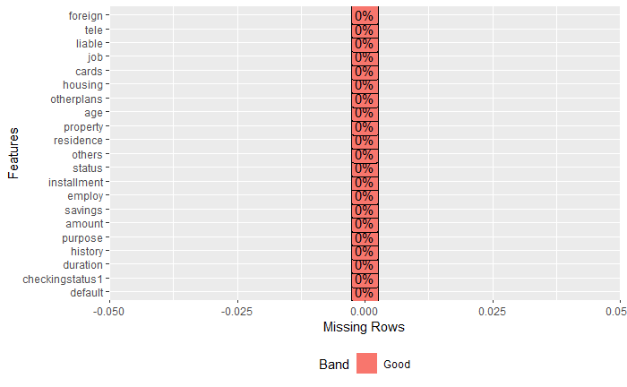

```r
plot_missing(creditdata)
```

###Exploratory Data Analysis Target variable

The response variable is default (As per the metadata 1 = Good, 2 = Bad) however the variable has been coded to 0 = Good and 1 = Bad in the dataset.

Let’s take a look at the proportions of default and the checkingstatus1 using the gmodels R package. We will use the checkingstatus1 variable as an example to understand the WOE calculations.

```r
# Create a base dataset copy for the woe models
creditdata_base <- creditdata

# Use the CrossTable function from gmodels package on default and checkingstatus1
gmodels::CrossTable(creditdata$default,
                    creditdata$checkingstatus1,prop.r= FALSE, prop.c =FALSE, prop.t=FALSE, chisq = TRUE)
```

```
   Cell Contents
|-------------------------|
|                       N |
| Chi-square contribution |
|-------------------------|


Total Observations in Table:  1000


                   | creditdata$checkingstatus1
creditdata$default |         less0 |   low0to200DM | highover200DM |     noaccount |     Row Total |
-------------------|---------------|---------------|---------------|---------------|---------------|
                 0 |           139 |           164 |            49 |           348 |           700 |
                   |        14.535 |         3.136 |         0.544 |        18.901 |               |
-------------------|---------------|---------------|---------------|---------------|---------------|
                 1 |           135 |           105 |            14 |            46 |           300 |
                   |        33.915 |         7.317 |         1.270 |        44.102 |               |
-------------------|---------------|---------------|---------------|---------------|---------------|
      Column Total |           274 |           269 |            63 |           394 |          1000 |
-------------------|---------------|---------------|---------------|---------------|---------------|


Statistics for All Table Factors


Pearson's Chi-squared test
------------------------------------------------------------
Chi^2 =  123.7209     d.f. =  3     p =  1.218902e-26
```

Categorical Variables To visualize distributions for the categorical features, let’s view frequency bar charts using DataExplorer.

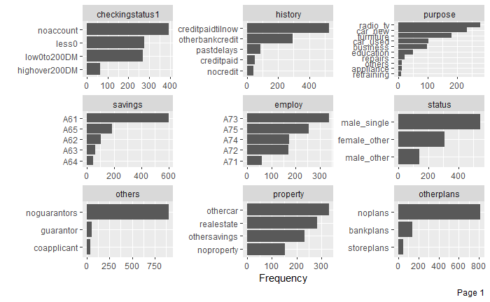

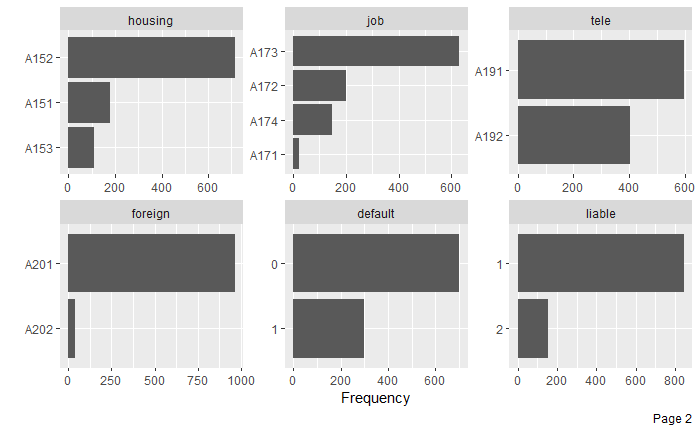

```r
# Barplot of categorical features using DataExplorer.
creditdata %>%
      plot_bar()
```

From these barplots it appears that the majority of the loans are made by single males, however there is no data for single females. Most loans are used for purchasing a radio/ television, then new cars and majority of borrowers have low savings or no account with this bank. The borrowers are mostly foreign, skilled workers with existing property.

### Numeric Variables

Now let’s take a look at the default variable against the numeric variables as density plots.

```r
# Use keep function from purrr, where columns are numeric ie TRUE are kept for our plots, then use purrr map function to plot a density plot for each numeric variable by default value
creditdata %>%
      select(age,duration,amount) %>%
      map(~ggplot(creditdata, aes(x = .)) +
                geom_density(aes(fill=as.factor(default)),alpha=0.3) +
                scale_fill_viridis_d()) # New ggplot v3.0.0 includes viridis palette
```

[output not shown]

###Feature Engineering Before we fit models we will subjectively group the continuous numeric variables to binned categorical variables based on visualising cut-off points in the EDA above. This is called coarse binning as we will group values with similar risk, in as few bins as possible. With the new group variables, we will remove the original continuous variables.

```r
# Create a new age_group variable, with buckets based on the density distribution above
creditdata <- creditdata %>%
  mutate(age_group=factor(case_when(
  .$age <  25 ~ "25less",
  .$age >= 25 & .$age <= 29 ~ "25to29",
  .$age >= 30 & .$age <= 39 ~ "30to39",
  .$age >= 40 & .$age <= 49 ~ "40to49",
  .$age >= 50 & .$age <= 59 ~ "50to59",
  .$age >= 60 & .$age <= 70 ~ "60over",
  .$age >= 70 ~ "6")))
# Remove the original age variable to avoid feature interactions
creditdata <- creditdata %>%
      dplyr::select(-age)
# Create a new amount_group variable, with buckets based on the density distribution above
creditdata <- creditdata %>%
  mutate(amount_group=factor(case_when(
  .$amount <  1250 ~ "1250less",
  .$amount >= 1250 & .$amount <= 5000 ~ "1250to5000",
  .$amount >= 5000  ~ "5000over")))
# Remove the original amount variable to avoid feature interactions
creditdata <- creditdata %>%
      dplyr::select(-amount)
# Create a new  duration_group variable, with buckets based on the density distribution above. We will group the months into years, we see peaks at the incremental 12 month marks
creditdata <- creditdata %>%
  mutate(duration_group=factor(case_when(
  .$ duration <  12 ~ "1yearunder",
  .$ duration >= 12 & .$ duration <= 24 ~ "1to2year",
  .$ duration >= 24 & .$ duration <= 36 ~ "2to3year",
  .$ duration >= 36 & .$ duration <= 48 ~ "3to4year",
  .$ duration >= 48  ~ "4yearover")))
# Remove the original  duration variable to avoid feature interactions
creditdata <- creditdata %>%
      dplyr::select(- duration)
```

### Training

Split the data into training and test sets following the Data Camp course steps in Chapter 1. Here we will use a 70:30 split between training and test sets and create splits for the base dataset for WOE binning and one which will be feature engineered with coarse binning.

```r
# Set seed of 123 for reproduceability
set.seed(123)
# Store row numbers for training set: index_train using randomly assigned observations
index_train <- sample(1:nrow(creditdata), 0.7 * nrow(creditdata))
# Create training set: training with the index
training <- creditdata[index_train, ]
# Create test set: test with the index
test <- creditdata[-index_train, ]

# Store row numbers for training set: index_train using randomly assigned observations
index_train_base <- sample(1:nrow(creditdata_base), 0.7 * nrow(creditdata_base))
# Create training set: training with the index
training_base <- creditdata_base[index_train_base, ]
# Create test set: test with the index
test_base <- creditdata_base[-index_train_base, ]
```

### Model 2 - Logistic Model with WOE Binning

####Information Theory (WoE and IV)

We can use the Information R package to perform variable screening using weight-of-evidence (WOE) and information value (IV).

WOE and IV play two distinct roles when analyzing data: - WOE describes the relationship between a predictive variable and a binary target variable. - IV measures the strength of that relationship.

The WOE framework optimises the number of bins and cut off points based on a risk value. If the variable is numeric then the cut off will respect the ordering, but it may not respect the ordering of the categorical values.

Let’s view a summary of the information values.

```r
# Create a WOE table
IV <- create_infotables(data=creditdata_base,
                        y="default")
# Print the summary of the IV table information values. Thes IVs are derived from the WOE.
IV$Summary %>%
      knitr::kable()
```

[output not shown]

```r
# Filter out variables via missing rate, information value, identical value rate
creditdata_filt <- var_filter(creditdata_base, y="default")
# Print the remaining number variables of the filtered dataset
dim(creditdata_filt)[2]
```

[output not shown]

```r
# Weight of average (WOE) binning
bins <- woebin(creditdata_filt, y="default")
```

```r
# Let's visualise the bins created for the numeric variables age, duration and amount
woebin_plot(bins$age)
```

[output not shown]

```r
# Convert train and test sets original input data to WOE values based on WOE binning
training_woe <- woebin_ply(training_base, bins)
```

```
[INFO] converting into woe values ...
```

```r
## Warning in e$fun(obj, substitute(ex), parent.frame(), e$data): already
## exporting variable(s): dt, xs
test_woe <- woebin_ply(test_base, bins)
```

```
[INFO] converting into woe values ...
```

```r
## Warning in e$fun(obj, substitute(ex), parent.frame(), e$data): already
## exporting variable(s): dt, xs
# Fit a logistic model
glm_model2 <- glm(default ~ ., family = "binomial", data = training_woe)
prediction_prob2 <- predict(glm_model2, newdata = test_woe, type = "response")
# Calculate the ROC
ROC_2 <- pROC::roc(test_woe$default,prediction_prob2)
# AUC for fourth model
AUC2 <- auc(ROC_2)
AUC2
```

[output not shown]

```r
## Area under the curve: 0.7951
# KS for fourth model
prediction_2 <- ROCR::prediction(prediction_prob2,test_woe$default)
perf_2 <- ROCR::performance(prediction_2,"tpr","fpr")
KS2 <- max(attr(perf_2,'y.values')[[1]]-attr(perf_2,'x.values')[[1]])
KS2
```

```
[1] 0.4620098
```